# Bayesian Model Packages

João Neto

October 2014

## Bayesian First Aid (cont.)

### Test of Proportions

A lot of questions out there involves estimating the proportion or relative frequency of success of two or more groups (where success could be a saved life, a click on a link, or a happy baby) and there exists a little known R function that does just that, `prop.test`. Here we’ll use its Bayesian version `bayes.prop.test`.

This is an extension of the binomial test which estimates the underlying relative frequency of success given a number of trials.

For $m$ different trials, in the i-th trial there were $x_1$ successes out of $n_i$ trials, so:

$x_i \sim \text{Binomial}(\theta_i, n_i)$

$\theta_i \sim \text{Beta}(1,1)$

Here’s an eg with two trials:

```r
trial.1 <- c( 43, 275)
trial.2 <- c(170,1454)
model <- bayes.prop.test(trial.1, trial.2)
model
```

```
##
##  Bayesian First Aid propotion test
##
## data: trial.1 out of trial.2
## number of successes:    43,  275
## number of trials:      170, 1454
## Estimated relative frequency of success [95% credible interval]:
##   Group 1: 0.26 [0.19, 0.32]
##   Group 2: 0.19 [0.17, 0.21]
## Estimated group difference (Group 1 - Group 2):
##   0.07 [-0.0034, 0.13]
## The relative frequency of success is larger for Group 1 by a probability
## of 0.975 and larger for Group 2 by a probability of 0.025 .
```

It seems that the first trial has more successes by around 7%. However this is not very solid evidence since the 95% confidence interval includes 0 even if barely.

We can calculate the probability that the difference between the two trials is small (say 5%):

```r
ts <- as.data.frame(model)
head(ts)
```

```
##   theta1 theta2 x_pred1 x_pred2
## 1 0.3004 0.1976      46     305
## 2 0.2749 0.1769      58     279
## 3 0.2518 0.1836      39     263
## 4 0.2867 0.1751      48     258
## 5 0.2024 0.1986      36     309
## 6 0.2417 0.1900      47     282
```

```r
diff <- mean(abs( ts$theta1 - ts$theta2 ) < 0.05) # check Kruschke's ROPE
diff
```

```
## [1] 0.3277
```

So, there’s a 33% that the relative frequency of successes in the two trials is equivalent, which is weak evidence for the ‘no difference’ hypothesis.

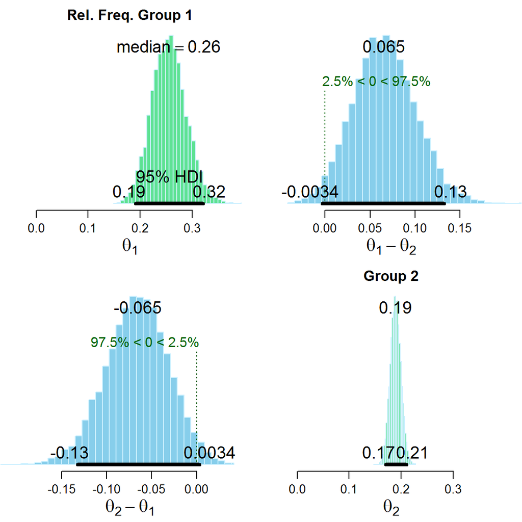

```r
plot(model)
```

```r
diagnostics(model)
```

```
##
## Iterations = 1:5000
## Thinning interval = 1
## Number of chains = 3
## Sample size per chain = 5000
##
##   Diagnostic measures
##                    mean     sd mcmc_se n_eff  Rhat
## theta[1]          0.256  0.033   0.000 14727 1.000
## theta[2]          0.190  0.010   0.000 14791 1.000
## x_pred[1]        43.451  8.024   0.067 14311 1.000
## x_pred[2]       275.637 20.968   0.175 14385 1.001
## theta_diff[1,2]   0.066  0.035      NA    NA    NA
##
## mcmc_se: the estimated standard error of the MCMC approximation of the mean.
## n_eff: a crude measure of effective MCMC sample size.
## Rhat: the potential scale reduction factor (at convergence, Rhat=1).
##
##   Model parameters and generated quantities
## theta: The relative frequency of success
## x_pred: Predicted number of successes in a replication
## theta_diff[i,j]: the difference between two groups (theta[i] - theta[j])
```

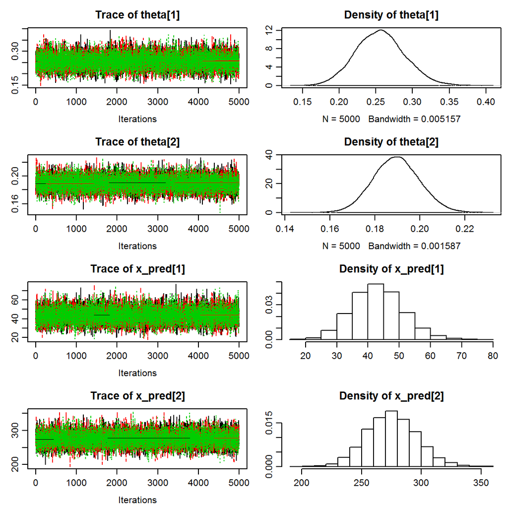

```r
model.code(model)
```

```
## ### Model code for the Bayesian First Aid  ###
## ### alternative to the test of proportions ###
## require(rjags)
##
## # Setting up the data
## x <- c(43, 275)
## n <- c(170, 1454)
##
## # The model string written in the JAGS language
## model_string <- "model {
##   for(i in 1:length(x)) {
##     x[i] ~ dbinom(theta[i], n[i])
##     theta[i] ~ dbeta(1, 1)
##     x_pred[i] ~ dbinom(theta[i], n[i])
##   }
## }"
##
## # Running the model
## model <- jags.model(textConnection(model_string), data = list(x = x, n = n),
##                     n.chains = 3, n.adapt=1000)
## samples <- coda.samples(model, c("theta", "x_pred"), n.iter=5000)
##
## # Inspecting the posterior
## plot(samples)
## summary(samples)
##
## # You can extract the mcmc samples as a matrix and compare the thetas
## # of the groups. For example, the following shows the median and 95%
## # credible interval for the difference between Group 1 and Group 2.
## samp_mat <- as.matrix(samples)
## quantile(samp_mat[, "theta[1]"] - samp_mat[, "theta[2]"], c(0.025, 0.5, 0.975))
```

Let’s see an eg with four groups:

```r
smokers  <- c(83, 90, 129, 70)
patients <- c(86, 93, 136, 82)
model <- bayes.prop.test(smokers, patients)
model
```

```
##
##  Bayesian First Aid propotion test
##
## data: smokers out of patients
## number of successes:   83,  90, 129,  70
## number of trials:      86,  93, 136,  82
## Estimated relative frequency of success [95% credible interval]:
##   Group 1: 0.96 [0.91, 0.99]
##   Group 2: 0.96 [0.92, 0.99]
##   Group 3: 0.94 [0.90, 0.98]
##   Group 4: 0.85 [0.77, 0.92]
## Estimated pairwise group differences (row - column) with 95 % cred. intervals:
##                         Group
##            2               3               4
##   1        0             0.01            0.11
##     [-0.064, 0.055] [-0.045, 0.072]  [0.023, 0.2]
##   2                      0.02            0.11
##                     [-0.042, 0.072]  [0.025, 0.2]
##   3                                      0.09
##                                      [0.014, 0.18]
```

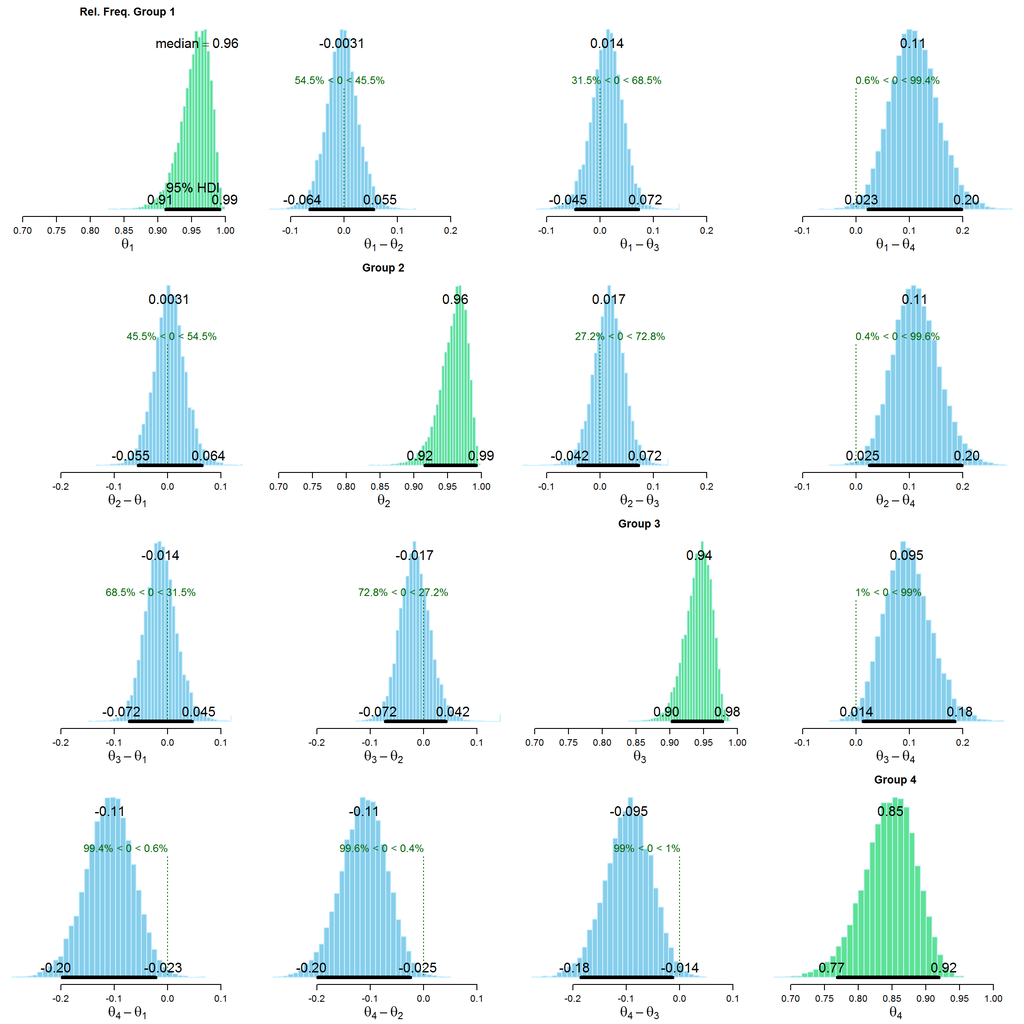

```r
plot(model)
```

The 4th group seems slighty different from the others.

```r
model.code(model)
```

```
## ### Model code for the Bayesian First Aid  ###
## ### alternative to the test of proportions ###
## require(rjags)
##
## # Setting up the data
## x <- c(83, 90, 129, 70)
## n <- c(86, 93, 136, 82)
##
## # The model string written in the JAGS language
## model_string <- "model {
##   for(i in 1:length(x)) {
##     x[i] ~ dbinom(theta[i], n[i])
##     theta[i] ~ dbeta(1, 1)
##     x_pred[i] ~ dbinom(theta[i], n[i])
##   }
## }"
##
## # Running the model
## model <- jags.model(textConnection(model_string), data = list(x = x, n = n),
##                     n.chains = 3, n.adapt=1000)
## samples <- coda.samples(model, c("theta", "x_pred"), n.iter=5000)
##
## # Inspecting the posterior
## plot(samples)
## summary(samples)
##
## # You can extract the mcmc samples as a matrix and compare the thetas
## # of the groups. For example, the following shows the median and 95%
## # credible interval for the difference between Group 1 and Group 2.
## samp_mat <- as.matrix(samples)
## quantile(samp_mat[, "theta[1]"] - samp_mat[, "theta[2]"], c(0.025, 0.5, 0.975))
```

### Poisson Test

Given a set of counts per time period, and assuming a Poisson distribution, the goal is to estimate the $\lambda$ parameter of the Poisson. It assumes that every count comes from equal periods of time, and that the parameter is fixed, ie, all counts com from the same distribution.

```r
sales.per.period <- c(14,16,9,18,10,6,13)
poisson.test(x=sum(sales.per.period), T=length(sales.per.period),r=10) # r -- hypothesized rate
```

```
##
##  Exact Poisson test
##
## data:  sum(sales.per.period) time base: length(sales.per.period)
## number of events = 86, time base = 7, p-value = 0.06345
## alternative hypothesis: true event rate is not equal to 10
## 95 percent confidence interval:
##   9.827 15.173
## sample estimates:
## event rate
##      12.29
```

The bayes version uses the following model:

$x \sim \text{Poisson}(\lambda_{\text{total}})$

$\lambda_{\text{total}} = \lambda . T$

$\lambda \sim \text{Gamma}(0.5,0.00001)$

The $\text{Gamma}(0.5,0.00001)$ is the JAGS-friendly approximation of the Jeffrey’s prior for the parameter of the Poisson (which is $p(\lambda) \propto 1/\sqrt{\lambda}$).

Using `bayes.poisson.text`:

```r
model <- bayes.poisson.test(x=sum(sales.per.period), T=length(sales.per.period), r=10)
model
```

```
##
##  Bayesian Fist Aid poisson test - one sample
##
## number of events: 86, time periods: 7
## Estimated event rate:
##   12
## 95% credible interval:
##   9.7 15
## The event rate is more than 10 by a probability of 0.969
## and less than 10 by a probability of 0.031  .
```

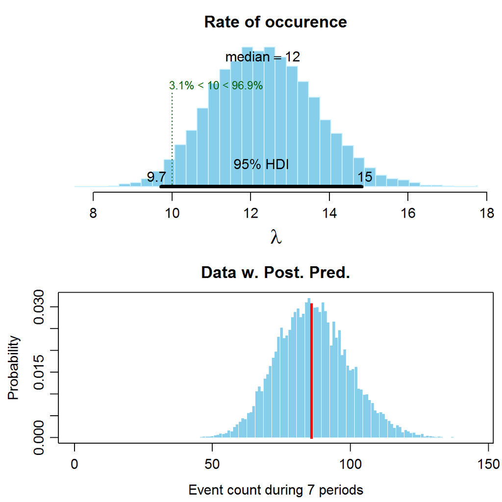

```r
plot(model)
```

```r
diagnostics(model)
```

```
##
## Iterations = 101:5100
## Thinning interval = 1
## Number of chains = 3
## Sample size per chain = 5000
##
##   Diagnostic measures
##         mean     sd mcmc_se n_eff  Rhat
## lambda 12.35  1.325   0.011 15313 1.001
## x_pred 86.45 13.083   0.104 15741 1.001
##
## mcmc_se: the estimated standard error of the MCMC approximation of the mean.
## n_eff: a crude measure of effective MCMC sample size.
## Rhat: the potential scale reduction factor (at convergence, Rhat=1).
##
##   Model parameters and generated quantities
## lambda: the rate of the process.
## x_pred: predicted event count during 7 periods.
```

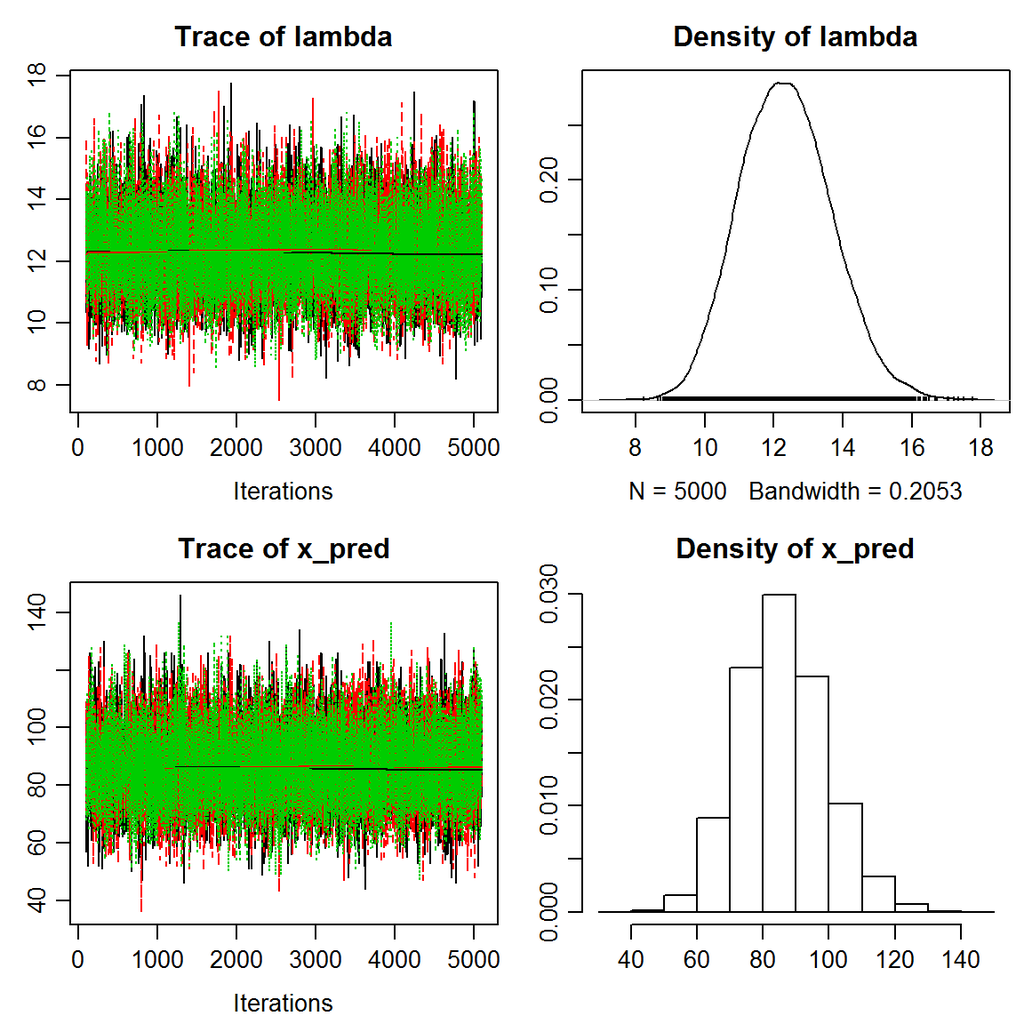

```r
model.code(model)
```

```
## ### Model code for the Bayesian First Aid one sample Poisson test ###
## require(rjags)
##
## # Setting up the data
## x <- 86
## t <- 7
##
## # The model string written in the JAGS language
## model_string <- "model {
##   x ~ dpois(lambda * t)
##   lambda ~ dgamma(0.5, 0.00001)
##   x_pred ~ dpois(lambda * t)
## }"
##
## # Running the model
## model <- jags.model(textConnection(model_string), data = list(x = x, t = t), n.chains = 3)
## samples <- coda.samples(model, c("lambda", "x_pred"), n.iter=5000)
##
## # Inspecting the posterior
## plot(samples)
## summary(samples)
```

The test accepts two different counts and compare its ratios. In the following eg we are comparing if the first group, that was X-rayed, the cancer rate is 1.5 higher than in the 2nd group, the control group:

```r
cancer.cases <- c(41,15)
person.per.thousand  <- c(28.011,19.025)
model <- bayes.poisson.test(x=cancer.cases, T=person.per.thousand, r=1.5)
model
```

```
##
##  Bayesian Fist Aid poisson test - two sample
##
## number of events: 41 and 15, time periods: 28.011 and 19.025
##
##   Estimates [95% credible interval]
## Group 1 rate: 1.5 [1.0, 1.9]
## Group 2 rate: 0.80 [0.42, 1.2]
## Rate ratio (Group 1 rate / Group 2 rate):
##               1.8 [1.1, 3.5]
##
## The event rate of group 1 is more than 1.5 times that of group 2 by a probability
## of 0.757 and less than 1.5 times that of group 2 by a probability of 0.243 .
```

So, there is evidence, around 75%, that the cancer rate after the patients being X-rayed, is higher than 1.5 times the control group.

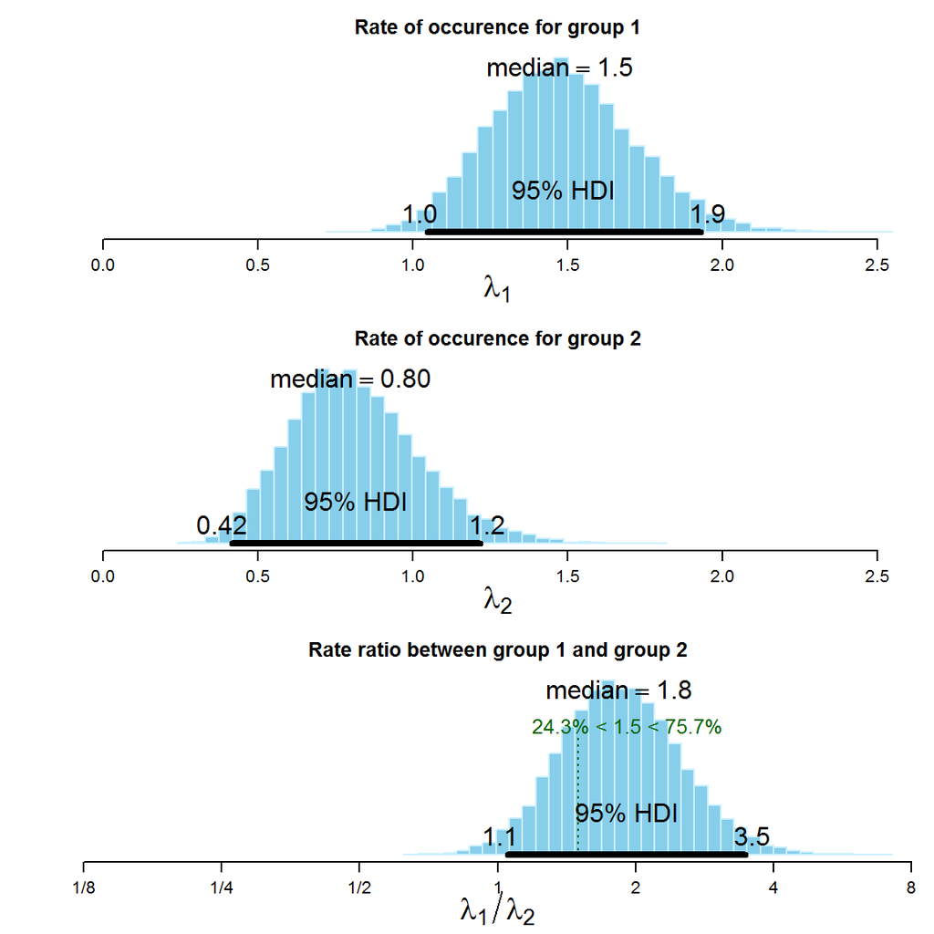

```r
plot(model)
```

```r
diagnostics(model)
```

[output not shown]

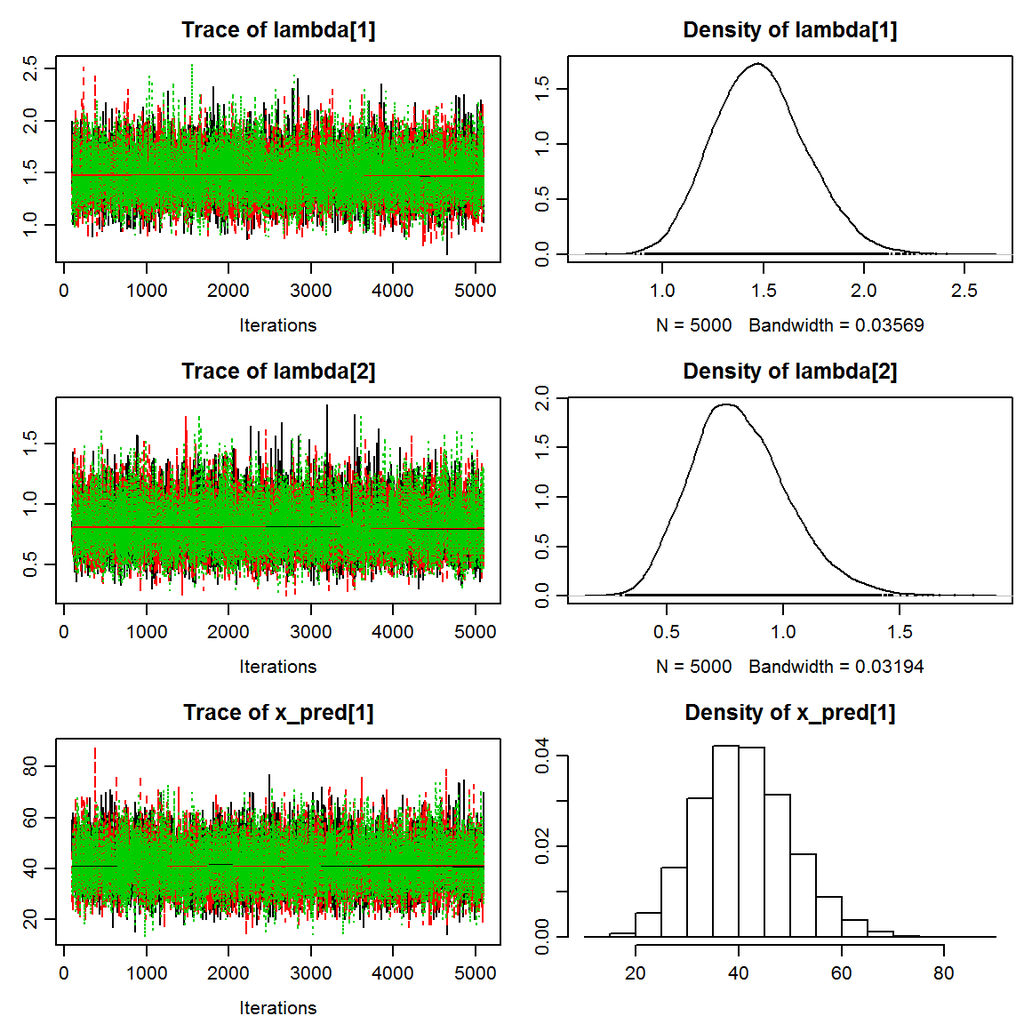

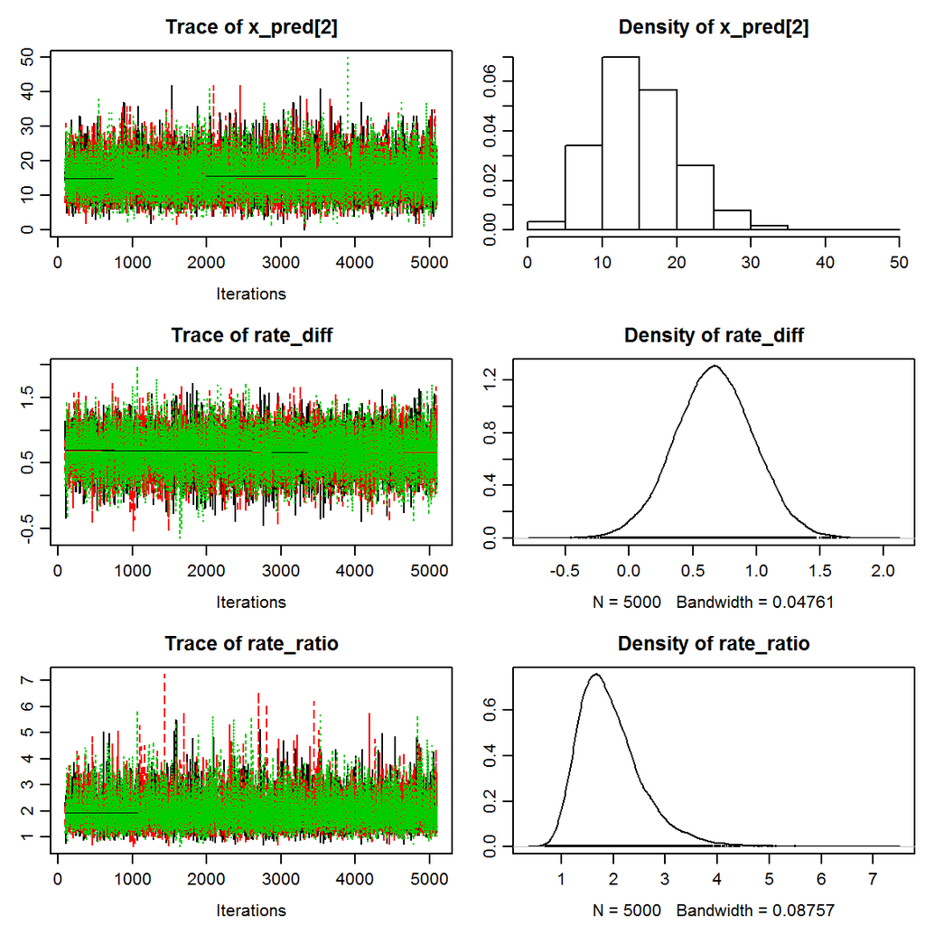

```r
model.code(model)
```

```
## ### Model code for the Bayesian First Aid two sample Poisson test ###
## require(rjags)
##
## # Setting up the data
## x <- c(41, 15)
## t <- c(28.011, 19.025)
##
## # The model string written in the JAGS language
## model_string <- "model {
##   for(group_i in 1:2) {
##     x[group_i] ~ dpois(lambda[group_i] * t[group_i])
##     lambda[group_i] ~ dgamma(0.5, 0.00001)
##     x_pred[group_i] ~ dpois(lambda[group_i] * t[group_i])
##   }
##   rate_diff <- lambda[1] - lambda[2]
##   rate_ratio <- lambda[1] / lambda[2]
## }"
##
## # Running the model
## model <- jags.model(textConnection(model_string), data = list(x = x, t = t), n.chains = 3)
## samples <- coda.samples(model, c("lambda", "x_pred", "rate_diff", "rate_ratio"), n.iter=5000)
##
## # Inspecting the posterior
## plot(samples)
## summary(samples)
```

It’s possible to add Poisson tests for more than two groups. Just copy-paste the R and JAGS code above, and change the input data for longer vectors. Then update the `for(group_i in 1:2)` to the required group size.

# Zelig package

Zelig is a unified framework for a large range of statistical models. Here in we’ll check [its](http://cran.r-project.org/web/packages/Zelig/vignettes/manual-bayes.pdf) bayesian models.

```r
library(MCMCpack)
library(Zelig)
```

## Bayesian Logistic Regression

A logistic model for $p_i = P(Z_i=1|X_i)$ is

$logit(p_i) = \log(\frac{p_i}{1-p_i}) = \beta_0 + \beta_1 \log(x_i)$

$\beta_0, \beta_1 \sim U(-\infty,+\infty)$

The model option for `zelig` is `model = "logit.bayes"`. Here’s an eg of training and testing using the bayesian logistic regression (check [here](http://web.cse.ohio-state.edu/~kulis/teaching/788_sp12/scribe_notes/lecture6.pdf) for more info):

```r
head(mtcars)
```

```
##                    mpg cyl disp  hp drat    wt  qsec vs am gear carb
## Mazda RX4         21.0   6  160 110 3.90 2.620 16.46  0  1    4    4
## Mazda RX4 Wag     21.0   6  160 110 3.90 2.875 17.02  0  1    4    4
## Datsun 710        22.8   4  108  93 3.85 2.320 18.61  1  1    4    1
## Hornet 4 Drive    21.4   6  258 110 3.08 3.215 19.44  1  0    3    1
## Hornet Sportabout 18.7   8  360 175 3.15 3.440 17.02  0  0    3    2
## Valiant           18.1   6  225 105 2.76 3.460 20.22  1  0    3    1
```

```r
set.seed(101)
n <- nrow(mtcars)
sample.set <- sample(1:n, 0.7*n)
train.set  <- mtcars[sample.set,]
test.set   <- mtcars[-sample.set,]

# model the probability of a manual transmission in a vehicle based on its engine horsepower & weight
z.out <- zelig(am ~ hp + wt, model = "logit.bayes", data = train.set, verbose=FALSE, cite=FALSE)
# test a new record:
x.out <- setx(z.out, wt=test.set[1,"wt"], hp=test.set[1,"hp"]) # this is test.set[1,]
s.out <- sim(z.out, x = x.out)
summary(s.out)
```

```
##
## Model:  logit.bayes
## Number of simulations:  1000
##
## Values of X
##            (Intercept) hp   wt
## Merc 450SE           1 93 2.32
## attr(,"assign")
## [1] 0 1 2
##
## Expected Value: E(Y|X)
##             mean  sd   50% 2.5% 97.5%
## Merc 450SE 0.934 0.1 0.974 0.63     1
##
## Predicted Value: Y|X
##                0     1
## Merc 450SE 0.068 0.932
```

```r
test.set[1,"am"] # compare with real value
```

```
## [1] 1
```

```r
# check the entire test set
ams <- rep(NA, nrow(test.set))
for(i in 1:nrow(test.set)) {

  x.out <- setx(z.out, wt=test.set[i,"wt"], hp=test.set[i,"hp"])
  s.out <- sim(z.out, x = x.out)

  ams[i] <- which.max(s.out$stats$`Predicted Value: Y|X`)-1
}
table(test.set$`am`, ams, dnn = c("real","predicted"))
```

```
##     predicted
## real 0 1
##    0 4 0
##    1 1 5
```

To check more bayesian models from this package check [Zelig’s manual](http://cran.r-project.org/web/packages/Zelig/vignettes/manual-bayes.pdf).

# Laplace’s Demon

This is another package that offers many different kinds of MCMC. Check their [webpage](http://www.bayesian-inference.com/software) for more info.

```r
# to install, download from http://www.bayesian-inference.com/softwaredownload
install.packages(pkgs="path\\LaplacesDemon_[version].tar.gz", repos=NULL, type="source")

# check package documentation
vignette("BayesianInference")
vignette("LaplacesDemonTutorial")
vignette("Examples")
```

Let’s implement the following model ([ref](http://www.sumsar.net/blog/2013/06/three-ways-to-run-bayesian-models-in-r/)):

$y_i \sim \mathcal{N}(\mu,\sigma)$ $\mu \sim \mathcal{N}(0,100)$ $\sigma \sim \text{LogNormal}(0,4)$

and get some data:

```r
set.seed(1337)
y <- rnorm(20,10,5)
```

There is no special mechanism for keeping the parameters inside a bounded range, therefore $\sigma$ is sampled on the log-scale and then exponentiated to make sure it is always positive.

```r
library(LaplacesDemon)

model <- function(theta, data) {
  mu       <- theta[1]
  sigma    <- exp(theta[2])
  log_lik  <- sum( dnorm(data$y, mu, sigma, log=T) )  # sum ( log p(y_i|theta) )
  log_post <- log_lik + dnorm(mu, 0, 100, log=T) + dlnorm(sigma, 0, 4, log=T)

  # return list in package required format
  list(LP=log_post,
       Dev= -2*log_lik,
       Monitor=c(log_post,sigma),
       yhat=NA,
       parm=theta)
}

data.list <- list(N=length(y), y=y, mon.names=c("log_post","sigma"), parm.names=c("mu","log.sigma"))
mcmc.samples <- LaplacesDemon(Model=model,
                              Data=data.list,
                              Iterations=1e4,
                              Algorithm="HARM", # Hit-and-Run Metropolis, www.bayesian-inference.com/mcmcharm
                              Thinning=1
                             )
```

[output not shown]

[output cut: 87 more lines]

[output not shown]

We can present the results from the sampling:

```r
Consort(mcmc.samples)
```

```
##
## #############################################################
## # Consort with Laplace's Demon                              #
## #############################################################
## Call:
## LaplacesDemon(Model = model, Data = data.list, Iterations = 10000,
##     Thinning = 1, Algorithm = "HARM")
##
## Acceptance Rate: 0.4179
## Algorithm: Hit-And-Run Metropolis
## Covariance Matrix: (NOT SHOWN HERE; diagonal shown instead)
##        mu log.sigma
##   1.49688   0.02556
##
## Covariance (Diagonal) History: (NOT SHOWN HERE)
## Deviance Information Criterion (DIC):
##          All Stationary
## Dbar 127.733    127.733
## pD     1.866      1.866
## DIC  129.599    129.599
## Initial Values:
##        mu log.sigma
##    12.719     1.699
##
## Iterations: 10000
## Log(Marginal Likelihood): -62.64
## Minutes of run-time: 0.03
## Model: (NOT SHOWN HERE)
## Monitor: (NOT SHOWN HERE)
## Parameters (Number of): 2
## Posterior1: (NOT SHOWN HERE)
## Posterior2: (NOT SHOWN HERE)
## Recommended Burn-In of Thinned Samples: 0
## Recommended Burn-In of Un-thinned Samples: 0
## Recommended Thinning: 40
## Specs: (NOT SHOWN HERE)
## Status is displayed every 100 iterations
## Summary1: (SHOWN BELOW)
## Summary2: (SHOWN BELOW)
## Thinned Samples: 10000
```

[output cut: 28 more lines]

```
## 4. Each target distribution has an effective sample size (ESS)
##    of at least 100.
## 5. Each target distribution became stationary by
##    1 iteration.
##
## Laplace's Demon has not been appeased, and suggests
## copy/pasting the following R code into the R console,
## and running it.
##
## Initial.Values <- as.initial.values(mcmc.samples)
## mcmc.samples <- LaplacesDemon(Model, Data=data.list, Initial.Values,
##      Covar=NULL, Iterations=4e+05, Status=333333, Thinning=40,
##      Algorithm="HARM", Specs=list(alpha.star=NA, B=NULL)
##
## Laplace's Demon is finished consorting.
```

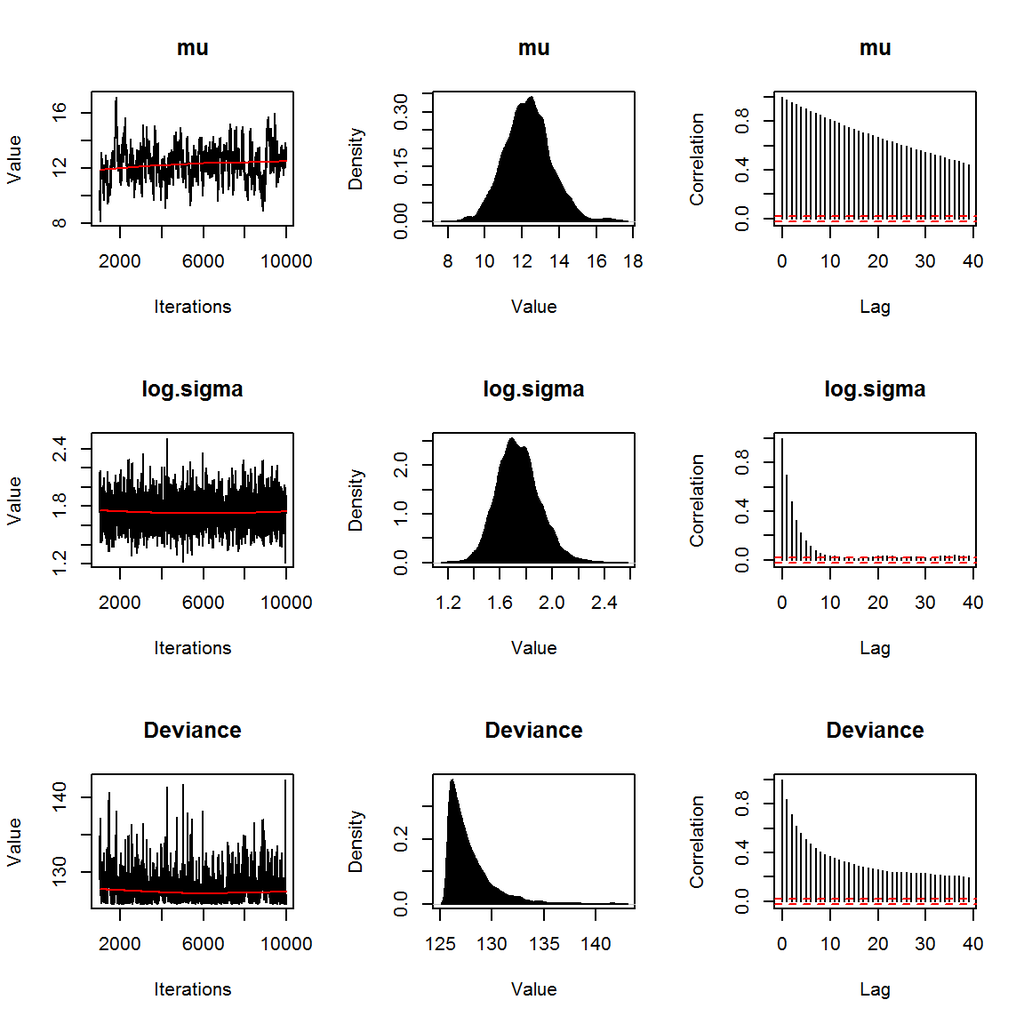

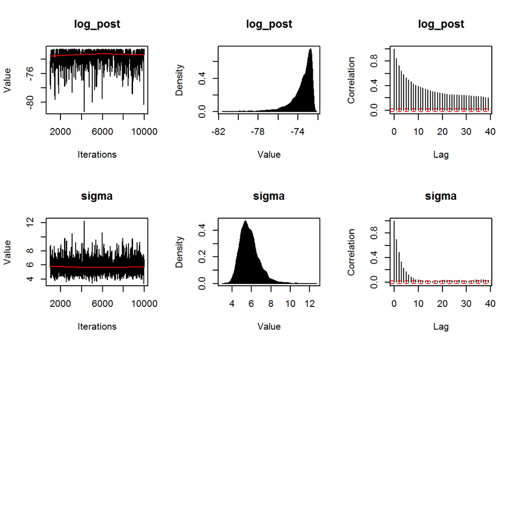

```r
plot(mcmc.samples, BurnIn=1e3, data.list)
```

The modelling with this package is less user-friendly since there is no declarative language like in BUGS, JAGS or STAN. However it has the possibility of lots of configuration options.